# Working with Geospatial Data in R

Dan McGlinn

2025-03-11

Home Page - http://dmcglinn.github.io/quant_methods/ GitHub Repo - https://github.com/dmcglinn/quant_methods ### Source Code Link https://raw.githubusercontent.com/dmcglinn/quant_methods/gh-pages/lessons/shapefiles_and_rasters.R

This lesson covers how to map and work with geospatial data in R. First let’s load the relevant libraries

```r
# install.packages(c("maps","sf", "raster", "ggplot2", "leaflet"))

library(maps)     # convenient pkg for maps of the world, state, and county
library(sf)       # spatial features package that is helpful working with polygons
library(raster)   # raster data class for working with grid data
library(ggplot2)  # has some mapping functions (geom_sf)
library(leaflet)  # for interactive maps
```

First, make some maps. The “maps” package has databases=“world”,“usa”,“state”, or “county”. (There are also a few for foreign countries like France and Italy.) In each database, you can plot any region or group of regions.

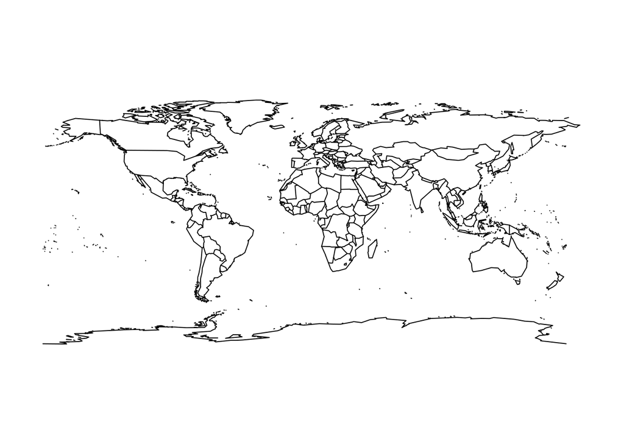

```r
world <- map(database="world")
```

```r
names(world)
```

```
## [1] "x"     "y"     "range" "names"
```

```r
head(world$names)
```

```
## [1] "Aruba"          "Afghanistan"    "Angola"         "Angola:Cabinda"
## [5] "Anguilla"       "Albania"
```

Names in world database can all be plot as a region. For example:

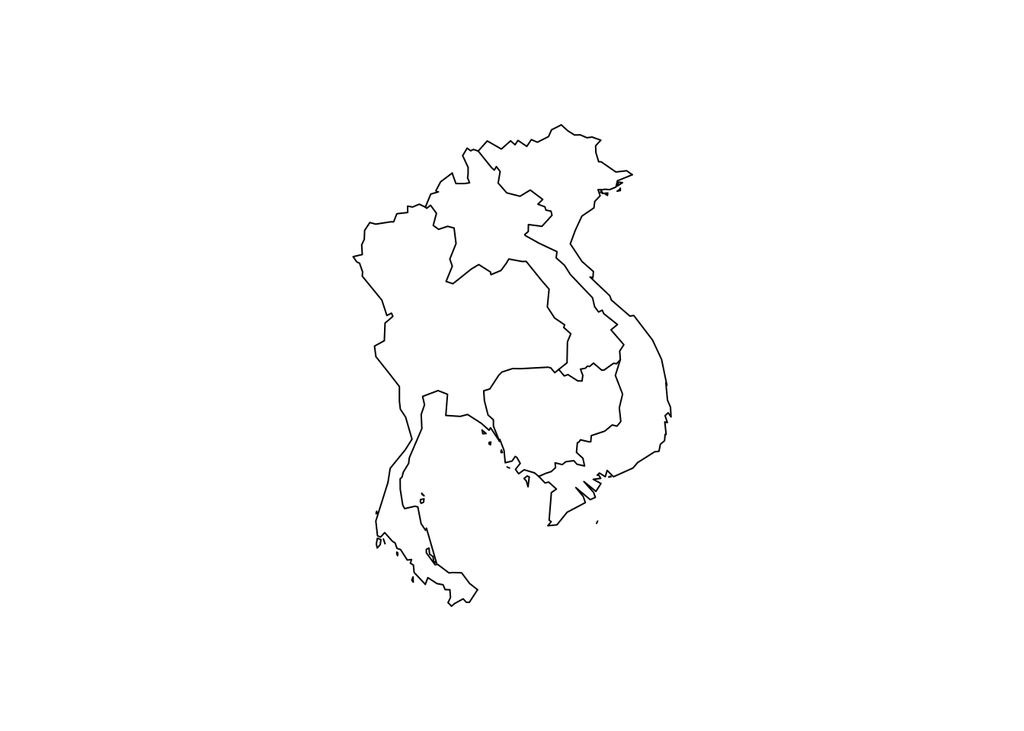

```r
map(database="world", regions=c("Cambodia", "Thailand", "Vietnam", "Laos"))
```

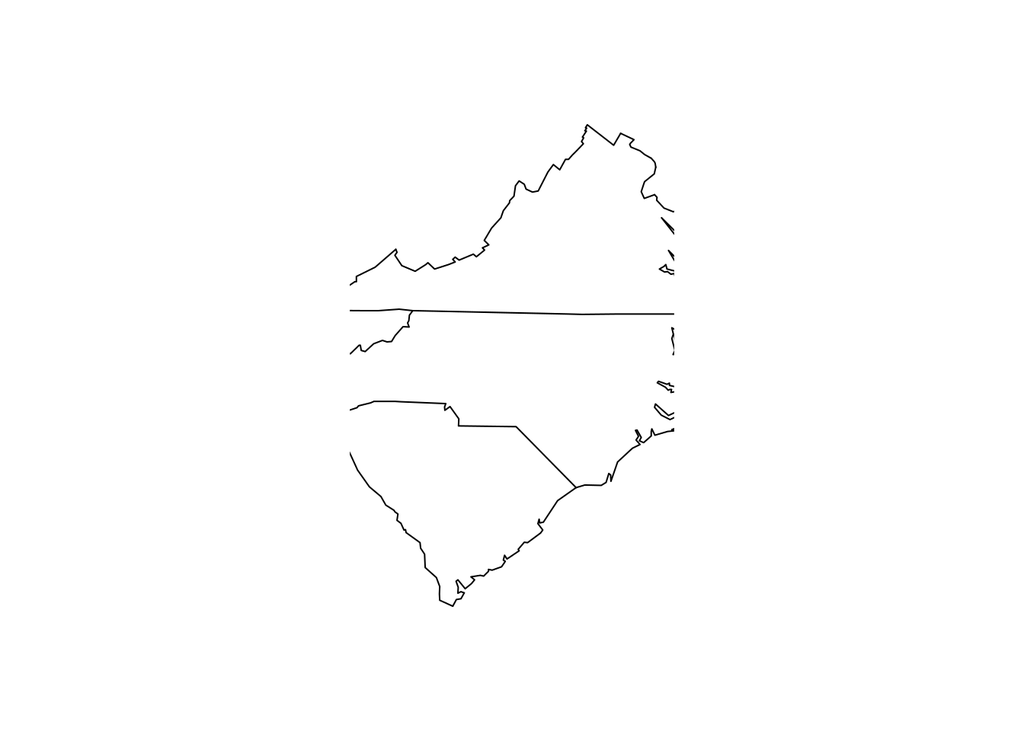

```r
map(database="state", regions=c("virginia", "north carolina", "south carolina"))
```

You can add cities using `map.cities()` function. Note: if the map is getting cropped on the edges close and clear the plotting window using `dev.off()` then manually widen the plotting window and try the `map()` function again - it should not crop the map if the window is big enough.

Let’s look at a county map:

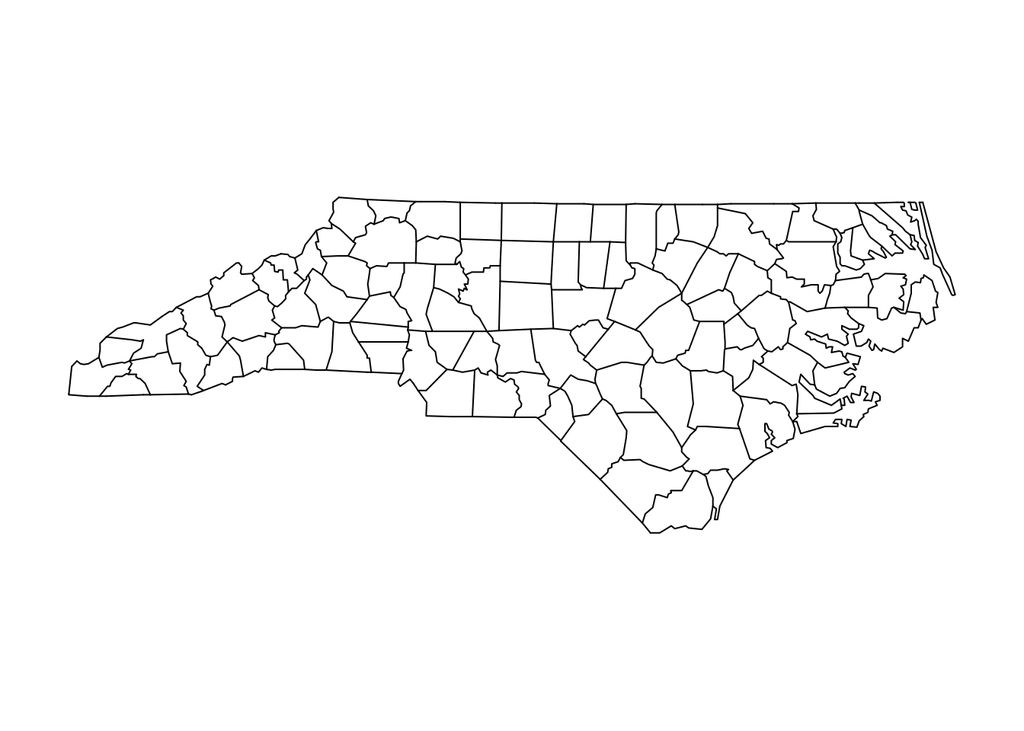

```r
nc_county <- map(database="county",regions="north carolina")
```

```r
head(nc_county$names)
```

```
## [1] "north carolina,alamance"  "north carolina,alexander"
## [3] "north carolina,alleghany" "north carolina,anson"
## [5] "north carolina,ashe"      "north carolina,avery"
```

```r
triangle <- map(database="county",
               regions=c("north carolina,orange","north carolina,wake","north carolina,durham"),
               fill=T, plot=F)
triangle$names
```

```
## [1] "north carolina,durham" "north carolina,orange" "north carolina,wake"
```

We can turn a map into a spatial polygons object and fill it with data, turning it into a spatial polygon dataframe.

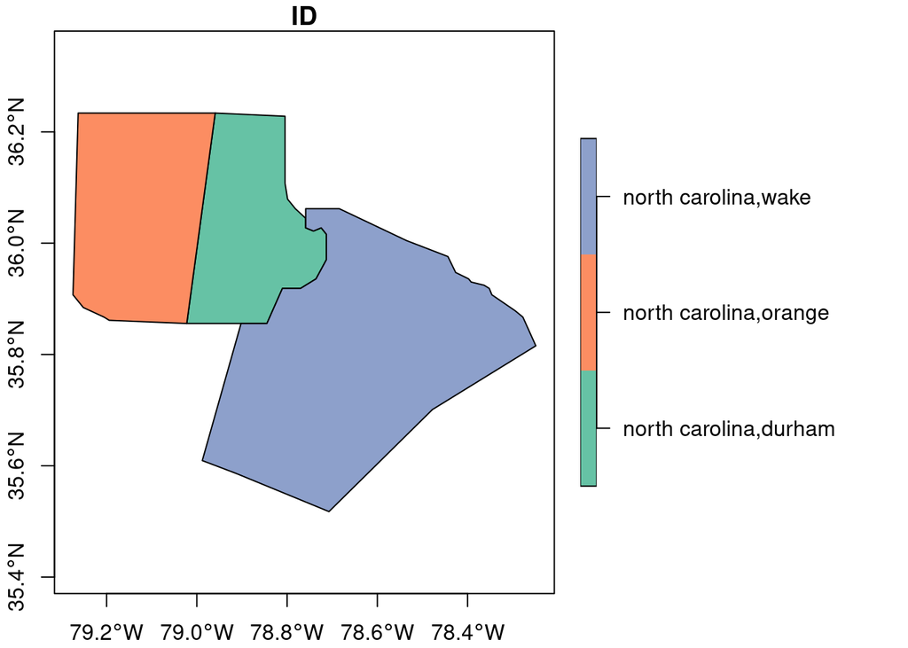

```r
tri_sf <- st_as_sf(triangle)

plot(tri_sf, axes=T)
```

add data to make spatial polygons data frame

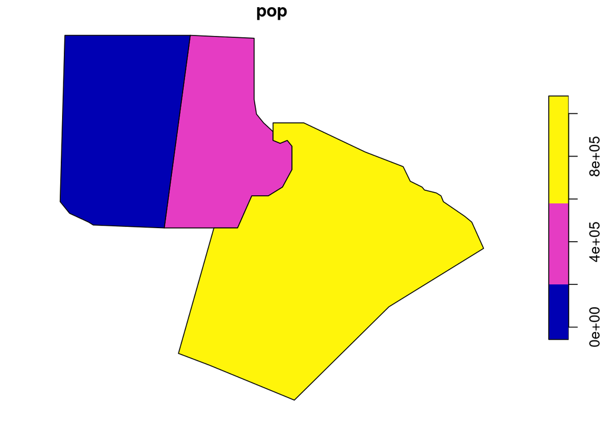

```r
population <- c(266132, 132272, 892409)

tri_sf$pop <- population

plot(tri_sf['pop'])
```

We can also use ggplot to produce a similar graphic with less hideous default colors

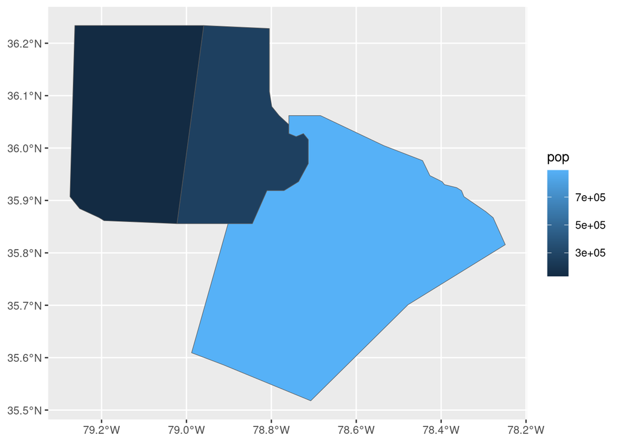

```r
ggplot(tri_sf) +
  geom_sf(aes(fill = pop))
```

If your data are in different projections, you need to change the projection so that they are all in the same coordinate reference system.

```r
world <- map(database="world", fill=T, plot=F)
world_longlat <- st_as_sf(world)

# Use function spTransform to transform to Mercator projection
world_merc <- st_transform(world_longlat, crs=st_crs("+proj=merc"))
# Lambert Azimuthal Equal Area
world_laea <- st_transform(world_longlat, crs=st_crs("+proj=laea"))
# sinusoidal
world_sinusoidal <- st_transform(world_longlat,
                                 crs=st_crs("+proj=sinu"))
```

plot the four together to see the difference. Mercator projection distorts area far from the equator. LAEA is accurately represents area but not angles. Sinusoidal is equal area and conserves distances along parallels.

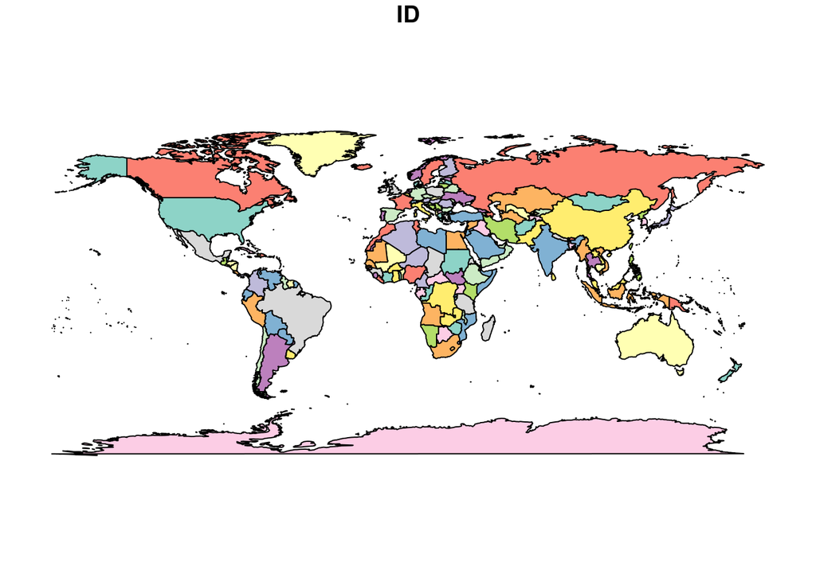

```r
par(mfrow=c(1,1))
plot(world_longlat)
```

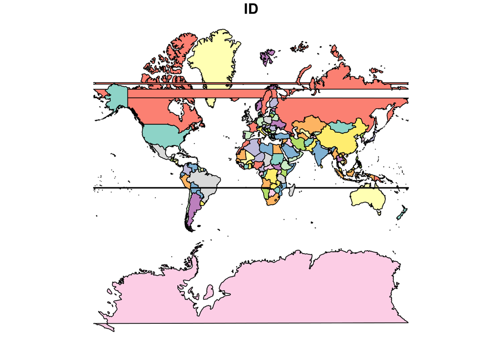

```r
plot(world_merc)
```

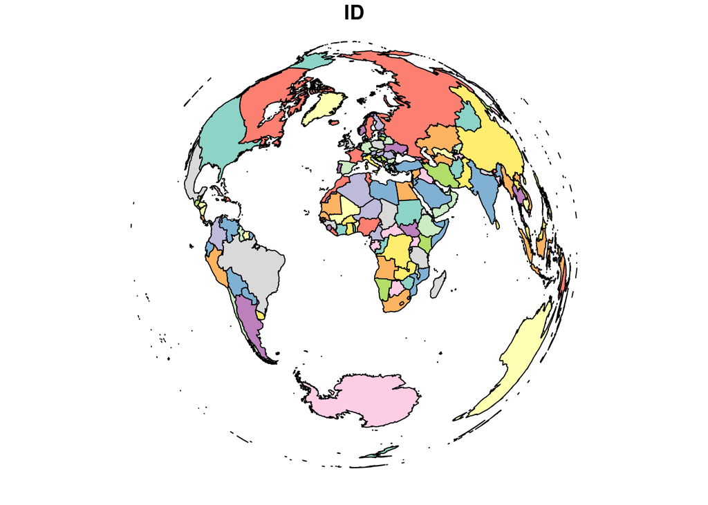

```r
plot(world_laea)
```

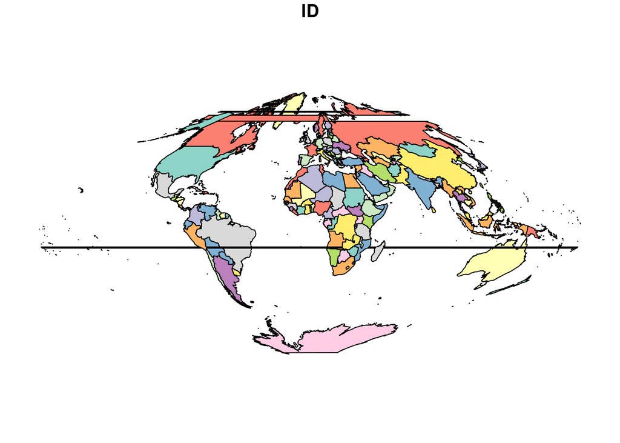

```r
plot(world_sinusoidal)
```

A four page cheat sheet about coordinate reference systems (CRSs), including projections, datums, and coordinate systems, and the use of these in R: https://www.nceas.ucsb.edu/sites/default/files/2020-04/OverviewCoordinateReferenceSystems.pdf A fun projection link: http://xkcd.com/977/

OK, some slightly more complicated stuff. Data from MODIS fire detentions in the US in 2021. metadata and data link for MODIS fire data available at: https://fsapps.nwcg.gov/afm/data/fireptdata/modisfire_2021_conus.htm

To download the data use:

```r
download.file('https://fsapps.nwcg.gov/afm/data/fireptdata/modis_fire_2021_365_conus_shapefile.zip',
              destfile = './data/modis_fire_2021_365_conus_shapefile.zip')
unzip('./data/modis_fire_2021_365_conus_shapefile.zip', exdir = './data/')
```

read in data

```r
fire2021 <- sf::st_read(dsn = './data/modis_fire_2021_365_conus.shp')
```

the shape file is read in as a data.frame with spatial attributes

```r
class(fire2021)
```

```
## [1] "sf"         "data.frame"
```

```r
names(fire2021)   # provides names of data table
```

```
##  [1] "AREA"      "PERIMETER" "FIRE_"     "FIRE_ID"   "LAT"       "LONG"
##  [7] "DATE"      "JULIAN"    "GMT"       "TEMP"      "SPIX"      "TPIX"
## [13] "SRC"       "SAT_SRC"   "CONF"      "FRP"       "geometry"
```

```r
dim(fire2021)     # dimensions of data table (1 row per spatial feature)
```

```
## [1] 242079     17
```

```r
st_crs(fire2021)  # retrieves coordinate reference system
```

```
## Coordinate Reference System:
##   User input: NAD83
##   wkt:
## GEOGCRS["NAD83",
##     DATUM["North American Datum 1983",
##         ELLIPSOID["GRS 1980",6378137,298.257222101,
##             LENGTHUNIT["metre",1]]],
##     PRIMEM["Greenwich",0,
##         ANGLEUNIT["degree",0.0174532925199433]],
##     CS[ellipsoidal,2],
##         AXIS["latitude",north,
##             ORDER[1],
##             ANGLEUNIT["degree",0.0174532925199433]],
##         AXIS["longitude",east,
##             ORDER[2],
##             ANGLEUNIT["degree",0.0174532925199433]],
##     ID["EPSG",4269]]
```

make a map of Julian day of each fire

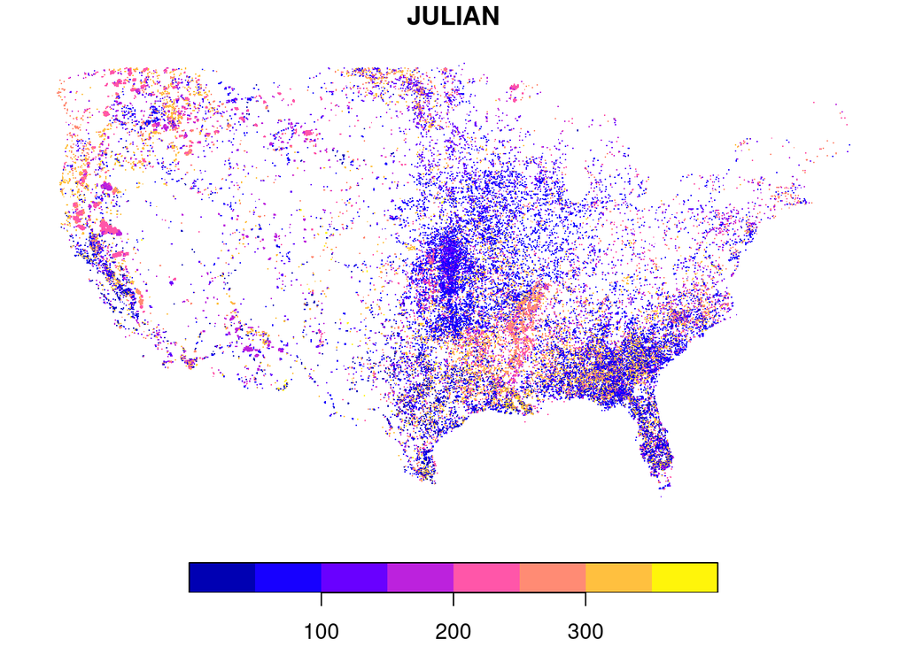

```r
plot(fire2021["JULIAN"], pch = '.')
```

alternatively use ggplot (a bit slower option in this case)

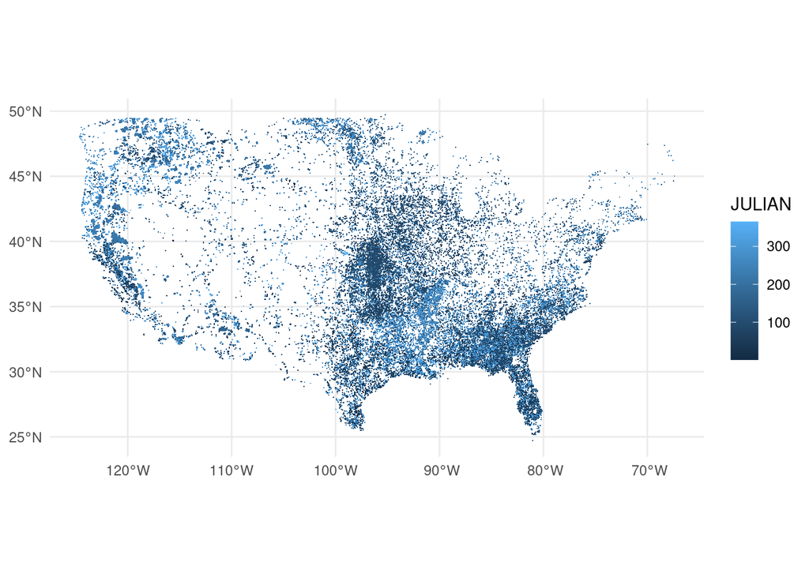

```r
ggplot(fire2021) +
  geom_sf(aes(col = JULIAN), pch = '.') +
  theme_minimal()
```

get summary statistics for each attribute just like we would for a dataframe

```r
summary(fire2021)
```

```
##       AREA     PERIMETER     FIRE_           FIRE_ID            LAT
##  Min.   :0   Min.   :0   Min.   :     1   Min.   :   124   Min.   :19.44
##  1st Qu.:0   1st Qu.:0   1st Qu.: 60520   1st Qu.:259314   1st Qu.:34.35
##  Median :0   Median :0   Median :121040   Median :462191   Median :40.01
##  Mean   :0   Mean   :0   Mean   :121040   Mean   :480743   Mean   :39.15
##  3rd Qu.:0   3rd Qu.:0   3rd Qu.:181560   3rd Qu.:750844   3rd Qu.:43.23
##  Max.   :0   Max.   :0   Max.   :242079   Max.   :922322   Max.   :49.72
##       LONG              DATE                JULIAN           GMT
##  Min.   :-124.64   Min.   :2021-01-01   Min.   :  1.0   Min.   : 241
##  1st Qu.:-120.57   1st Qu.:2021-04-26   1st Qu.:116.0   1st Qu.: 954
##  Median :-113.13   Median :2021-07-27   Median :208.0   Median :1817
##  Mean   :-106.60   Mean   :2021-07-09   Mean   :190.5   Mean   :1518
##  3rd Qu.: -93.12   3rd Qu.:2021-08-30   3rd Qu.:242.0   3rd Qu.:1930
##  Max.   : -67.39   Max.   :2021-12-31   Max.   :365.0   Max.   :2214
##       TEMP            SPIX            TPIX           SRC
##  Min.   :300.0   Min.   :1.000   Min.   :1.000   Length:242079
##  1st Qu.:312.5   1st Qu.:1.100   1st Qu.:1.000   Class :character
##  Median :321.5   Median :1.300   Median :1.100   Mode  :character
##  Mean   :329.1   Mean   :1.621   Mean   :1.216
##  3rd Qu.:337.1   3rd Qu.:1.900   3rd Qu.:1.300
##  Max.   :508.8   Max.   :4.800   Max.   :2.000
##    SAT_SRC               CONF             FRP                    geometry
##  Length:242079      Min.   :  0.00   Min.   :    0.00   POINT        :242079
##  Class :character   1st Qu.: 55.00   1st Qu.:   14.50   epsg:4269    :     0
##  Mode  :character   Median : 73.00   Median :   30.40   +proj=long...:     0
##                     Mean   : 70.99   Mean   :   92.17
##                     3rd Qu.: 93.00   3rd Qu.:   72.10
##                     Max.   :100.00   Max.   :10433.30
```

```r
fire <- subset(fire2021, JULIAN > 182)
class(fire)
```

```
## [1] "sf"         "data.frame"
```

```r
names(fire)
```

```
##  [1] "AREA"      "PERIMETER" "FIRE_"     "FIRE_ID"   "LAT"       "LONG"
##  [7] "DATE"      "JULIAN"    "GMT"       "TEMP"      "SPIX"      "TPIX"
## [13] "SRC"       "SAT_SRC"   "CONF"      "FRP"       "geometry"
```

```r
dim(fire)
```

```
## [1] 159875     17
```

```r
summary(fire)
```

```
##       AREA     PERIMETER     FIRE_           FIRE_ID            LAT
##  Min.   :0   Min.   :0   Min.   :     3   Min.   :164409   Min.   :19.44
##  1st Qu.:0   1st Qu.:0   1st Qu.: 44674   1st Qu.:373536   1st Qu.:37.86
##  Median :0   Median :0   Median : 94868   Median :649520   Median :40.78
##  Mean   :0   Mean   :0   Mean   :100282   Mean   :586477   Mean   :40.88
##  3rd Qu.:0   3rd Qu.:0   3rd Qu.:146410   3rd Qu.:821217   3rd Qu.:45.61
##  Max.   :0   Max.   :0   Max.   :242078   Max.   :922322   Max.   :49.46
##       LONG              DATE                JULIAN           GMT
##  Min.   :-124.64   Min.   :2021-07-02   Min.   :183.0   Min.   : 245
##  1st Qu.:-121.18   1st Qu.:2021-07-29   1st Qu.:210.0   1st Qu.: 629
##  Median :-118.85   Median :2021-08-18   Median :230.0   Median :1741
##  Mean   :-112.31   Mean   :2021-08-27   Mean   :239.4   Mean   :1414
##  3rd Qu.:-107.59   3rd Qu.:2021-09-13   3rd Qu.:256.0   3rd Qu.:1934
##  Max.   : -67.56   Max.   :2021-12-31   Max.   :365.0   Max.   :2214
##       TEMP            SPIX            TPIX           SRC
##  Min.   :300.0   Min.   :1.000   Min.   :1.000   Length:159875
##  1st Qu.:313.7   1st Qu.:1.100   1st Qu.:1.000   Class :character
##  Median :324.5   Median :1.300   Median :1.100   Mode  :character
##  Mean   :332.5   Mean   :1.646   Mean   :1.224
##  3rd Qu.:341.6   3rd Qu.:1.900   3rd Qu.:1.300
##  Max.   :508.8   Max.   :4.800   Max.   :2.000
##    SAT_SRC               CONF             FRP                   geometry
##  Length:159875      Min.   :  0.00   Min.   :    0.0   POINT        :159875
##  Class :character   1st Qu.: 56.00   1st Qu.:   17.2   epsg:4269    :     0
##  Mode  :character   Median : 78.00   Median :   37.1   +proj=long...:     0
##                     Mean   : 73.28   Mean   :  113.5
##                     3rd Qu.: 99.00   3rd Qu.:   88.6
##                     Max.   :100.00   Max.   :10433.3
```

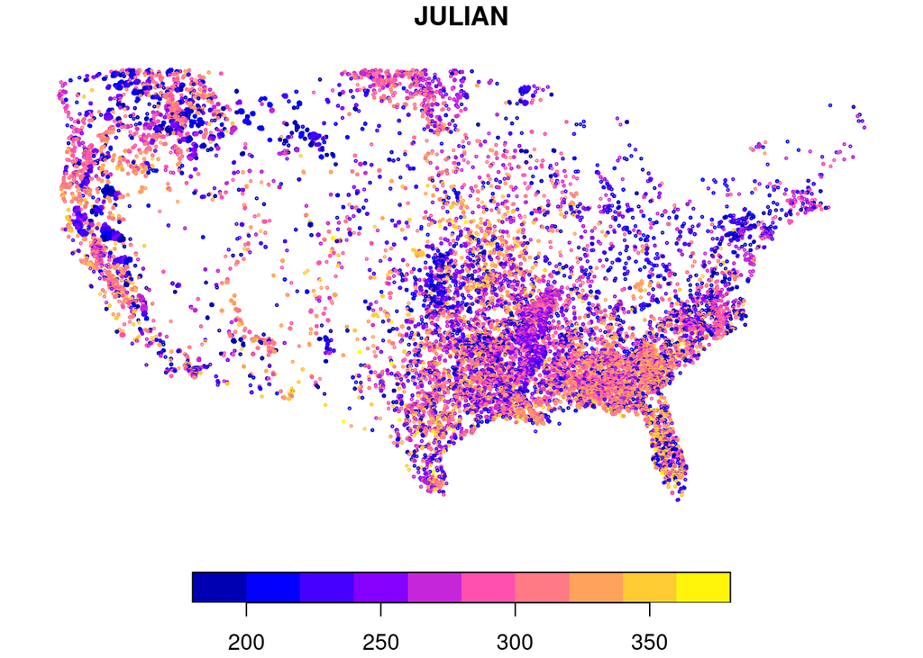

```r
plot(fire['JULIAN'], cex = 0.25)
```

It is a little more difficult to do a geographicaly defined subset. For example, let’s select the fires in SC. First we’ll identify which state each fire occurred in, then subset the ones from SC.

```r
USA <- map(database='state', plot=FALSE, fill=TRUE)
names(USA)
```

```
## [1] "x"     "y"     "range" "names"
```

```r
USA$names
```

```
##  [1] "alabama"                         "arizona"
##  [3] "arkansas"                        "california"
##  [5] "colorado"                        "connecticut"
##  [7] "delaware"                        "district of columbia"
##  [9] "florida"                         "georgia"
## [11] "idaho"                           "illinois"
## [13] "indiana"                         "iowa"
## [15] "kansas"                          "kentucky"
## [17] "louisiana"                       "maine"
## [19] "maryland"                        "massachusetts:martha's vineyard"
## [21] "massachusetts:main"              "massachusetts:nantucket"
## [23] "michigan:north"                  "michigan:south"
## [25] "minnesota"                       "mississippi"
## [27] "missouri"                        "montana"
## [29] "nebraska"                        "nevada"
```

[output cut: 17 more lines]

```r
USA_sf <- st_as_sf(USA)
```

Let’s make sure projection of USA polygon is same as fire points

```r
USA_sf <- st_transform(USA_sf, st_crs(fire2021))
```

Now we overlay performs a “point in polygon” operation–meaning that it will return us a vector giving the index of which polygon in USA_sp each point in fire is. We then index that to names(USA_sp) to get the name of the state for that index.

```r
sf_use_s2(FALSE)
```

```
## Spherical geometry (s2) switched off
```

```r
fire_state <- st_intersection(fire2021, USA_sf)
```

```
## although coordinates are longitude/latitude, st_intersection assumes that they
## are planar
```

```r
firesc <- fire_state[grep("south carolina", fire_state$ID), ]
dim(firesc)
```

```
## [1] 3247   18
```

```r
addLegendToSFPlot <- function(values = c(0, 1), labels = c("Low", "High"),
                              palette = c("blue", "red"), ...){

    # Get the axis limits and calculate size
    axisLimits <- par()$usr
    xLength <- axisLimits[2] - axisLimits[1]
    yLength <- axisLimits[4] - axisLimits[3]

    # Define the colour palette
    colourPalette <- leaflet::colorNumeric(palette, range(values))

    # Add the legend
    plotrix::color.legend(xl=axisLimits[2] - 0.1*xLength, xr=axisLimits[2],
                          yb=axisLimits[3], yt=axisLimits[3] + 0.1 * yLength,
                          legend = labels, rect.col = colourPalette(values),
                          gradient="y", ...)
}
```

First make an SC spatial polygon to put around the fire points.

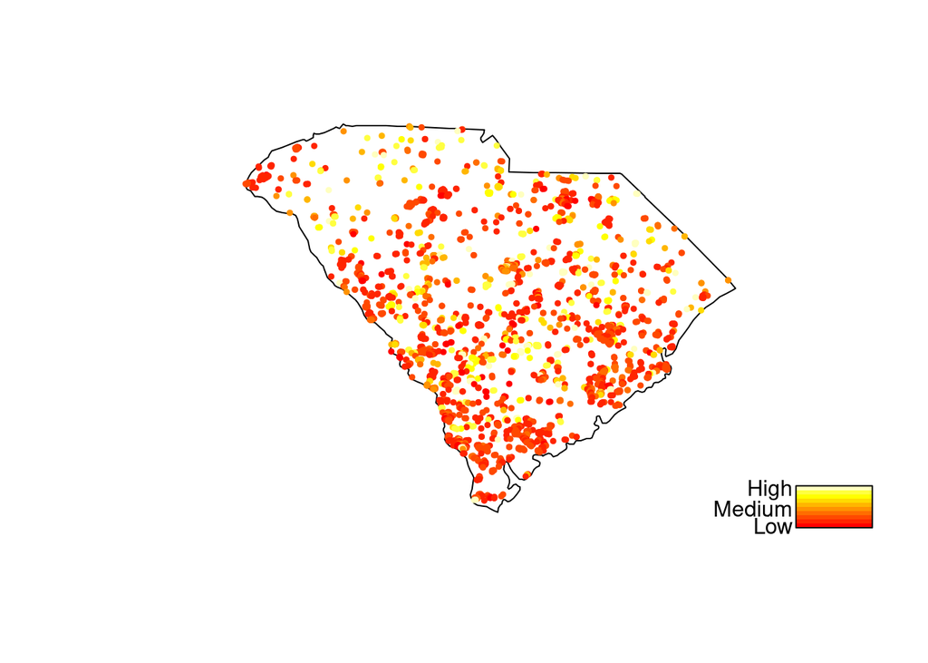

```r
SC <- map(database='state', regions='south carolina', fill=T,
          plot=F)

SC_st <- st_as_sf(SC)
SC_st <- st_transform(SC_st, crs=st_crs(firesc))

cuts <- cut(firesc$JULIAN, 10)
colors <- heat.colors(10)[as.numeric(cuts)]

plot(st_geometry(SC_st))
plot(st_geometry(firesc['JULIAN']), add = TRUE,
     col = colors, pch = 19, cex = 0.5)


addLegendToSFPlot(values = seq(from = 183, to = 363, length.out = 10),
                  labels = c("Low", "", "", "", "Medium", "", "", "", "", "High"),
                  palette = heat.colors(10))
```

Here’s where ggplot shines as it makes it easy to combine multiple maps

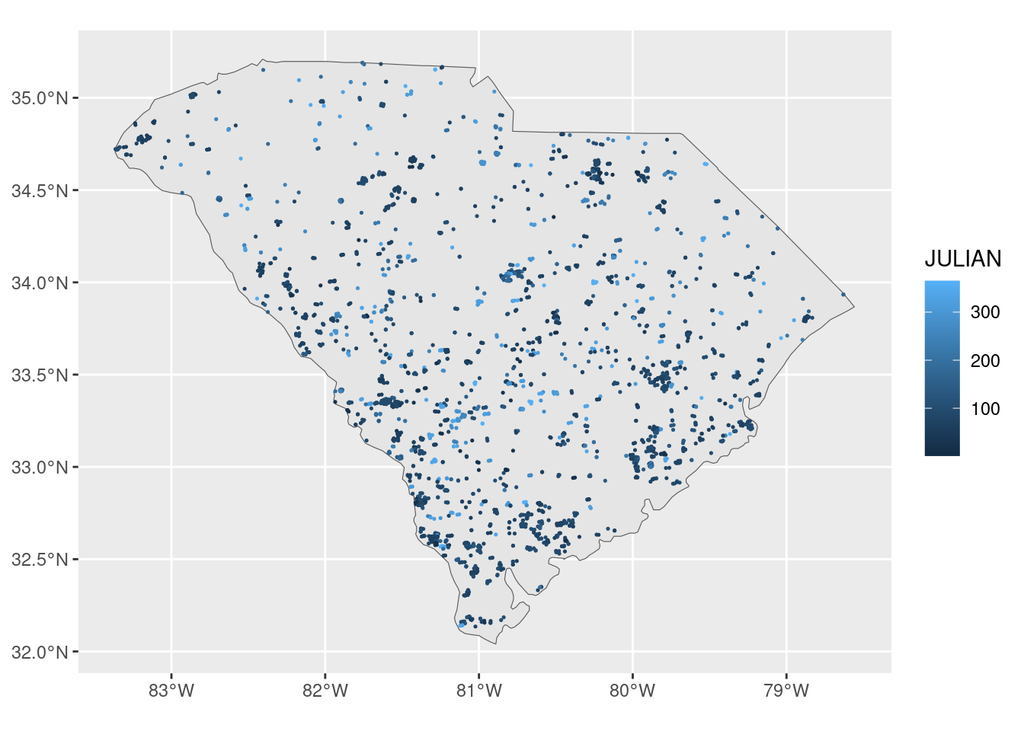

```r
ggplot() +
  geom_sf(data = SC_st) +                              # add in SC polygon
  geom_sf(data = firesc, aes(col = JULIAN), cex = 0.25)  # add in fire data
```

For the last step, let’s export this as a KML (readable by google earth) using write OGR and plot the locations of fires in SC in google earth. The first argument is the object we want to export, the second is the filename (by default it will go in our working directory), the layer we want to export, and the file format.

```r
write_sf(firesc, "firesctemp.kml", driver="kml")
```

## Rasters

Rasters are grids of data. A common data grid to work with is climate data. You can download an Rdata file of bioclim climate data here:

```r
## https://www.dropbox.com/s/gafxazc9575nf3j/bioclim_10m.Rdata?dl=0
```

let’s load load and plot the data

```r
load('./data/bioclim_10m.Rdata')
bioStack
```

```
## class      : RasterBrick
## dimensions : 900, 2160, 1944000, 19  (nrow, ncol, ncell, nlayers)
## resolution : 0.1666667, 0.1666667  (x, y)
## extent     : -180, 180, -60, 90  (xmin, xmax, ymin, ymax)
## crs        :  +proj=longlat +ellps=WGS84
## source     : memory
## names      :    mat,    mdr,    iso,  tseas,   tmax,   tmin,    tar,  twetq,  tdryq, twarmq, tcoldq,     ap,   pwet,   pdry,  pseas, ...
## min values :  -26.9,    0.9,    0.8,    7.2,   -5.9,  -54.7,    5.3,  -25.1,  -45.0,   -9.7,  -48.8,    0.0,    0.0,    0.0,    0.0, ...
## max values :   31.4,   21.1,    9.5, 2267.3,   48.9,   25.8,   72.5,   37.5,   36.4,   38.0,   28.9, 9916.0, 2088.0,  652.0,  261.0, ...
```

```r
class(bioStack)
```

```
## [1] "RasterBrick"
## attr(,"package")
## [1] "raster"
```

```r
names(bioStack)
```

```
##  [1] "mat"    "mdr"    "iso"    "tseas"  "tmax"   "tmin"   "tar"    "twetq"
##  [9] "tdryq"  "twarmq" "tcoldq" "ap"     "pwet"   "pdry"   "pseas"  "pwetq"
## [17] "pdryq"  "pwarmq" "pcoldq"
```

```r
projection(bioStack)  # this is unprojected latlong like the fire data
```

```
## [1] "+proj=longlat +ellps=WGS84"
```

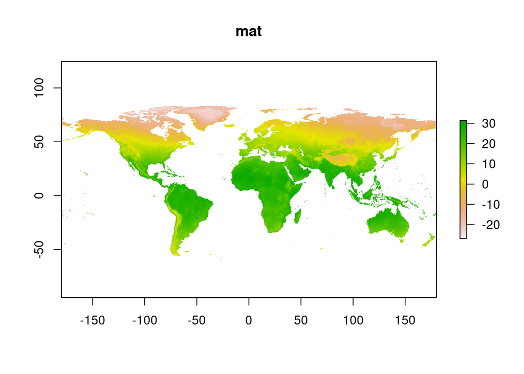

```r
plot(bioStack, "mat")
```

Let’s extract the historical climate data at each of our fire locations

```r
fire_climate <- extract(bioStack, firesc)
class(fire_climate)
```

```
## [1] "matrix" "array"
```

```r
head(fire_climate)
```

```
##       mat  mdr iso tseas tmax tmin  tar twetq tdryq twarmq tcoldq   ap pwet
## [1,] 15.0 13.7 4.0 738.4 31.6 -2.1 33.7   6.8  15.5   24.3    5.2 1300  131
## [2,] 15.0 13.7 4.0 738.4 31.6 -2.1 33.7   6.8  15.5   24.3    5.2 1300  131
## [3,] 15.1 13.6 4.0 740.1 31.6 -2.1 33.7   6.8  15.6   24.4    5.2 1267  128
## [4,] 15.0 13.7 4.0 738.4 31.6 -2.1 33.7   6.8  15.5   24.3    5.2 1300  131
## [5,] 15.2 13.0 3.9 746.9 31.5 -1.8 33.3   6.8  15.7   24.6    5.3 1209  123
## [6,] 15.3 13.0 3.9 745.1 31.6 -1.7 33.3   7.0  10.6   24.7    5.5 1220  126
##      pdry pseas pwetq pdryq pwarmq pcoldq
## [1,]   91     9   346   297    343    319
## [2,]   91     9   346   297    343    319
## [3,]   88    10   338   286    338    312
## [4,]   91     9   346   297    343    319
## [5,]   83    11   328   270    325    303
## [6,]   84    11   336   272    330    308
```

```r
nrow(fire_climate)
```

```
## [1] 3247
```

merge the two datasets

```r
firesc <- cbind(firesc, fire_climate)
head(firesc)
```

```
## Simple feature collection with 6 features and 36 fields
## Geometry type: POINT
## Dimension:     XY
## Bounding box:  xmin: -81.758 ymin: 35.166 xmax: -81.239 ymax: 35.19
## Geodetic CRS:  NAD83
##        AREA PERIMETER  FIRE_ FIRE_ID    LAT    LONG       DATE JULIAN  GMT
## 173259    0         0 173259  160772 35.190 -81.758 2021-06-30    181 1824
## 173260    0         0 173260  160771 35.190 -81.758 2021-06-30    181 1830
## 173303    0         0 173303   71672 35.183 -81.638 2021-04-05     95 1905
## 173316    0         0 173316  631657 35.181 -81.747 2021-07-06    187 1610
## 173409    0         0 173409  544371 35.167 -81.239 2021-04-13    103 1630
## 173418    0         0 173418  544370 35.166 -81.239 2021-04-13    103 1640
##         TEMP SPIX TPIX  SRC SAT_SRC CONF  FRP             ID  mat  mdr iso
## 173259 320.5  1.1  1.0 ssec       A   56 11.2 south carolina 15.0 13.7 4.0
## 173260 320.5  1.1  1.0 gsfc       A   56  8.6 south carolina 15.0 13.7 4.0
```

[output cut: 18 more lines]

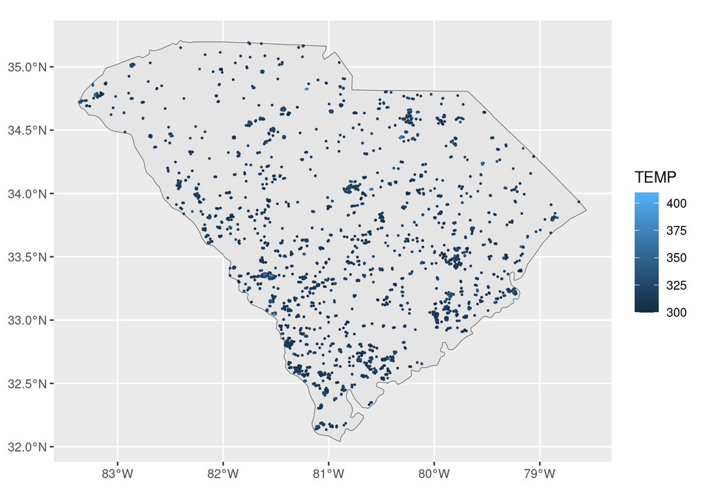

```r
# Fire temperatures in deg K at fire locations
ggplot() +
  geom_sf(data = SC_st) +
  geom_sf(data = firesc, aes(col = TEMP), cex = 0.25)
```